# STATISTICNA OBDELAVA PODATKOV VPLIVA SLANOSTI NA PSENICO

Tilen Sever

11 march 2017

Pri predmetu Rast in razvoj rastlin smo izvedli poskus v katerem smo preverjali vpliv slanosti (50, 100 in 200 mM NaCl) na razlicne sorte psenice (le te so Element (El), Euclide (Eu) in Vulcan (Vu)). V 36 lonckov (vsaka sorta trikrat z vsako koncentracijo soli in kontrola) smo posadili 15 semen kar smo kasneje razredcili na 10. Na rastlinah smo merili vec parametrov (masa poganjkov, vsebnost MDA poganjkov, masa korenin, vsebnost MDA korenin, delez klorofila a, delez klorofila b, delez klorofila a in b, transpiracija, dejanska fotokemicna ucinkovitost in potencialna fotokemicna ucinkovitost).

Za predmet Statisticna odbelava podatkov sem pridobljene podatke odelali s pomocjo Rstudia.

# 1 Uvoz podatkov

```r
library(readxl)

tabela <- read_excel("C:/Users/Menoetes/Documents/R/rezultati_pšenica_slanost2.xlsx",
    sheet = "tabela")
View(tabela)
```

```r
str(data)
```

```
## function (..., list = character(), package = NULL, lib.loc = NULL,
##     verbose = getOption("verbose"), envir = .GlobalEnv)
```

z ukazom `summary` pa priklicemo povzetek podatkov, ta nima smisla, saj podatki niso odbravnavani pravilno, R loci med posameznimi merjenimi parametri (stolpci), ne pa tudi med posamznimi sortami, ki se v stolpcih razlikujejo

```r
summary(tabela)
```

```
##   Vrsta_Kon          AVG-masa-pog    AVG-MDA-pog     AVG-masa-korenine
##  Length:36          Min.   :0.868   Min.   : 44.98   Min.   :0.225
##  Class :character   1st Qu.:3.081   1st Qu.: 92.16   1st Qu.:1.853
##  Mode  :character   Median :3.495   Median :130.05   Median :2.911
##                     Mean   :3.537   Mean   :138.13   Mean   :2.908
##                     3rd Qu.:3.882   3rd Qu.:171.94   3rd Qu.:3.582
##                     Max.   :6.205   Max.   :235.00   Max.   :9.169
##  AVG-MDA-korenine X(Chl a) [mg/g]   X(Chl b) [mg/g]   X (Chl a+b) [mg/g]
##  Min.   : 13.21   Min.   :0.03668   Min.   :0.07665   Min.   :0.1254
##  1st Qu.: 36.60   1st Qu.:4.21487   1st Qu.:1.73983   1st Qu.:5.9536
##  Median : 58.31   Median :4.66407   Median :2.21740   Median :6.8815
##  Mean   : 64.28   Mean   :4.24356   Mean   :2.25026   Mean   :6.4938
##  3rd Qu.: 99.91   3rd Qu.:4.79222   3rd Qu.:2.69490   3rd Qu.:7.4726
##  Max.   :122.77   Max.   :4.92362   Max.   :4.26321   Max.   :9.0484
##  AVG-transpiracija AVG-dejanska_foto_aktivnost
##  Min.   : 30.30    Min.   :725.8
##  1st Qu.: 53.26    1st Qu.:747.5
##  Median : 69.90    Median :755.1
##  Mean   : 70.15    Mean   :756.8
##  3rd Qu.: 88.74    3rd Qu.:767.1
##  Max.   :117.25    Max.   :789.2
##  AVG-potencialna_foto_aktivnost
##  Min.   :699.8
##  1st Qu.:765.4
##  Median :778.0
##  Mean   :772.7
##  3rd Qu.:787.1
##  Max.   :799.0
```

# 2 Analiza

najprej sem izracunal povprecje za vsako koncentracijo in sorto posebaj (tabela2 ima povprecja, tabela22 je isto, samo ohranjen ima stolpec Vrsta_Kon). S pomocjo `aggregate` zdruzim posamazne koncentracije in vrste v njihovih povprecjih (uporabim `FUN=mean`), rezultat je tabela z povprecji podatkov

```
##        AVG-masa-pog AVG-MDA-pog AVG-masa-korenine AVG-MDA-korenine
## El_K       4.480667   178.57750          4.956333         13.78341
## El_50      4.161333   170.29634          5.036667         37.67312
## El_100     3.314333   158.68862          3.331667         17.59065
## El_200     3.200000   230.58973          2.487667         34.03004
## Eu_K       4.341333    50.89110          1.676333         61.19302
## Eu_50      3.494000    66.97585          1.972333         41.34433
## Eu_100     3.152667   120.63413          3.155667         81.17481
## Eu_200     2.784333   103.70384          1.713333         48.89319
## Vu_K       3.359000   138.51754          2.816667        107.86225
## Vu_50      3.069000   133.33243          2.092667        116.74163
## Vu_100     3.619000   214.27202          2.959000        117.71165
## Vu_200     3.473000    91.07632          2.700000         93.40873
##        X(Chl a) [mg/g] X(Chl b) [mg/g] X (Chl a+b) [mg/g]
## El_K          4.807202        2.967630           7.774832
## El_50         4.630289        2.615167           7.245457
## El_100        4.495277        2.183666           6.678943
## El_200        3.119025        2.250750           5.369775
## Eu_K          4.793863        2.737911           7.531773
## Eu_50         3.190067        1.667828           4.857895
## Eu_100        4.155951        1.805923           5.961874
## Eu_200        4.766027        2.646505           7.412532
## Vu_K          4.228284        2.011081           6.239366
## Vu_50         4.514120        2.685746           7.199866
## Vu_100        4.201151        1.688149           5.889300
## Vu_200        4.021467        1.742761           5.764228
##        AVG-transpiracija AVG-dejanska_foto_aktivnost
## El_K            89.01111                    745.4167
## El_50          108.72778                    738.5000
## El_100          73.98889                    748.0833
## El_200          46.19444                    761.5833
## Eu_K            64.32778                    748.8333
## Eu_50           63.68333                    759.1667
## Eu_100          49.56667                    766.5000
## Eu_200          45.90556                    752.7500
## Vu_K            98.54444                    758.3333
## Vu_50           48.37778                    772.8333
## Vu_100          74.52778                    767.5833
## Vu_200          78.98333                    762.0833
##        AVG-potencialna_foto_aktivnost
## El_K                         774.0000
## El_50                        768.0833
## El_100                       750.5000
## El_200                       771.9167
## Eu_K                         761.8333
## Eu_50                        780.6667
## Eu_100                       776.4167
## Eu_200                       763.1667
## Vu_K                         758.9167
## Vu_50                        784.0833
## Vu_100                       789.8333
## Vu_200                       793.5000
```

Nato sem normaliziral podatke za vsako vrsto na njihovo kontrolo tako dobimo odstopanje posameznih tretmajev relativno glede na kontrolno skupino za vsako vrsto psenice posebaj (normtabela2 ima normalizirana povprecja podatkov iz tabela2).

```
##        AVG-masa-pog AVG-MDA-pog AVG-masa-korenine AVG-MDA-korenine
## El_K   1            1           1                 1
## El_50  0.9287308    0.9536271   1.016208          2.733221
## El_100 0.7396965    0.8886261   0.6722039         1.276218
## El_200 0.7141794    1.291259    0.5019167         2.468912
## Eu_K   1            1           1                 1
## Eu_50  0.8048219    1.316062    1.176576          0.675638
## Eu_100 0.7261978    2.370437    1.882482          1.326537
## Eu_200 0.6413544    2.03776     1.022072          0.7989995
## Vu_K   1            1           1                 1
## Vu_50  0.9136648    0.9625671   0.7429586         1.082322
## Vu_100 1.077404     1.546895    1.050533          1.091315
## Vu_200 1.033939     0.6575075   0.9585799         0.8660001
##        X(Chl a) [mg/g] X(Chl b) [mg/g] X (Chl a+b) [mg/g]
## El_K   1               1               1
## El_50  0.9631985       0.881231        0.9319117
## El_100 0.9351129       0.7358283       0.8590466
## El_200 0.6488234       0.7584334       0.6906612
## Eu_K   1               1               1
## Eu_50  0.6654481       0.609161        0.6449869
## Eu_100 0.8669317       0.6595989       0.7915631
## Eu_200 0.9941934       0.9666147       0.9841682
## Vu_K   1               1               1
## Vu_50  1.067601        1.335474        1.153942
## Vu_100 0.993583        0.8394236       0.9438941
## Vu_200 0.9510872       0.8665793       0.9238485
##        AVG-transpiracija AVG-dejanska_foto_aktivnost
## El_K   1                 1
## El_50  1.221508          0.9907211
## El_100 0.8312321         1.003577
## El_200 0.5189739         1.021688
## Eu_K   1                 1
## Eu_50  0.9899819         1.013799
## Eu_100 0.7705329         1.023592
## Eu_200 0.7136195         1.00523
## Vu_K   1                 1
## Vu_50  0.4909234         1.019121
## Vu_100 0.7562859         1.012198
## Vu_200 0.8014996         1.004945
##        AVG-potencialna_foto_aktivnost
## El_K   1
## El_50  0.9923557
## El_100 0.9696382
## El_200 0.9973084
## Eu_K   1
## Eu_50  1.024721
## Eu_100 1.019142
## Eu_200 1.00175
## Vu_K   1
## Vu_50  1.033161
## Vu_100 1.040738
## Vu_200 1.045569
```

Ker R nima funkcije za standardno napako, enacbo za njo shranim kot funkcijo `se`.
$$SE_{ \overline{x}} = \frac{s} {\sqrt n}$$

```r
se <- function(x){
serr <- sd(x)/sqrt(length(x))
return(serr)
}
```

Ker nisem uspel normalizirati podatke na kontrolo v ‘tabela’ lepo in na nacin, ki bi to omogocal z vecjo kolicino podatkov, sem uvozil novo tabelo z normaliziranimi vrednostmi (tabela4 ima normalizirane izvorne podatke).

```r
library(readxl)
tabela4<- read_excel("~/R/rezultati_pšenica_slanost2.xlsx",
    sheet = "tabela2")
View(tabela4)
```

Pridobim standardne napake normaliziraih podatkov v ‘tabeloSE’, spet uporabim `aggregate`, tokrat z `FUN = se`

```
##        Group.1     norm_MP  norm_MDA_P    norm_MK  norm_MDA_K  Chla_Qorm
## El_K      El_K 0.000000000 0.000000000 0.00000000 0.000000000 0.00000000
## El_50    El_50 0.117583060 0.005412971 0.43012598 0.015139530 0.02527337
## El_100  El_100 0.066792610 0.006164803 0.04051021 0.006212210 0.03548466
## El_200  El_200 0.072086220 0.012757150 0.10776589 0.011413363 0.32129056
## Eu_K      Eu_K 0.000000000 0.000000000 0.00000000 0.000000000 0.00000000
## Eu_50    Eu_50 0.176632885 0.050310271 0.28128458 0.012845010 0.32769125
## Eu_100  Eu_100 0.104327799 0.027639548 0.12083009 0.005423549 0.09193812
## Eu_200  Eu_200 0.221542949 0.127633204 0.51060349 0.083655309 0.01126070
## Vu_K      Vu_K 0.000000000 0.000000000 0.00000000 0.000000000 0.00000000
## Vu_50    Vu_50 0.043019528 0.040089220 0.25806852 0.029218568 0.04342573
## Vu_100  Vu_100 0.072554191 0.031539674 0.16563199 0.004355331 0.02112289
## Vu_200  Vu_200 0.009228937 0.007846129 0.33083272 0.033532343 0.10904468
##         Chlb_norm Sk_Chl_norm Transp_norm norm_AVG_dejanska_foto_aktivnost
## El_K   0.00000000  0.00000000  0.00000000                      0.000000000
## El_50  0.18712501  0.08572254  0.04883362                      0.005541435
## El_100 0.10985621  0.06355358  0.10041278                      0.011181107
## El_200 0.20949321  0.26610914  0.03816646                      0.005491593
## Eu_K   0.00000000  0.00000000  0.00000000                      0.000000000
## Eu_50  0.29247109  0.31456294  0.22117863                      0.007749250
## Eu_100 0.11549337  0.10023209  0.08504473                      0.015190602
## Eu_200 0.09647323  0.04205402  0.10060973                      0.008102378
## Vu_K   0.00000000  0.00000000  0.00000000                      0.000000000
## Vu_50  0.39765348  0.15371079  0.09193663                      0.004853860
## Vu_100 0.03262213  0.02481092  0.10656797                      0.010449966
## Vu_200 0.17919415  0.13022288  0.06899714                      0.010197305
##        norm_AVG-potencialna_foto_aktivnost
## El_K                           0.000000000
## El_50                          0.018540102
## El_100                         0.030030076
## El_200                         0.008615283
## Eu_K                           0.000000000
## Eu_50                          0.007350819
## Eu_100                         0.003902770
## Eu_200                         0.012252613
## Vu_K                           0.000000000
## Vu_50                          0.004857581
## Vu_100                         0.006778664
## Vu_200                         0.004496672
```

# 3 Izris podatkov za maso poganjkov

## 3.1 Plot

Najprej sem izrisal crtni graf samo za maso poganjkov, za prvo vrsto sem izrisal graf z pomocjo funkcije `plot`, za ostali dve sem sem narisal vrednosti na isti graf s pomocjo `points`. Standardne napake sem nanesel s pomocjo `segments` in `epsilon`.

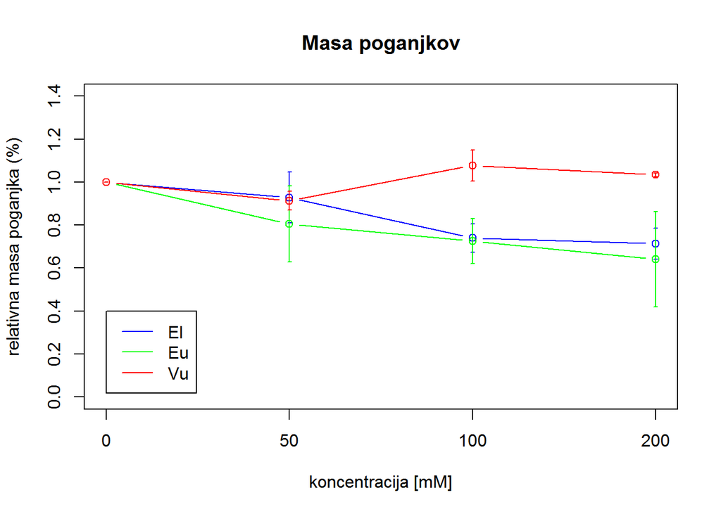

```r
x<-c(1:4) #ta vektor uporabim zato, da na x osi dobim samo stiri tocke, ki so enako oddaljene med sabo

el<-normtabela2[c('El_K','El_50','El_100','El_200'),'AVG-masa-pog']
eu<-normtabela2[c('Eu_K','Eu_50','Eu_100','Eu_200'),'AVG-masa-pog']
vu<-normtabela2[c('Vu_K','Vu_50','Vu_100','Vu_200'),'AVG-masa-pog']
#nevem zakaj, amopak zgornje vektorje shrani kot 'list', ker to otezuje nadaljne delo, jih spremenim v numericne vrednosti
el<-as.numeric(el)
eu<-as.numeric(eu)
vu<-as.numeric(vu)

elSE<-tabelaSE[c('El_K','El_50','El_100','El_200'),'norm_MP']
euSE<-tabelaSE[c('Eu_K','Eu_50','Eu_100','Eu_200'),'norm_MP']
vuSE<-tabelaSE[c('Vu_K','Vu_50','Vu_100','Vu_200'),'norm_MP']
#nevem zakaj, ampak slednje tri vektorje z standardnimi napakami zapise kot 'numeric' ze samo po sebi
plot(x,el, type = 'b', col='blue',ylim=c(0 , 1.4),xlab = 'koncentracija [mM]', ylab = 'relativna masa poganjka (%)',xaxt='n',main = 'Masa poganjkov')
points(x,eu, type = 'b', col='green')
points(x,vu, type='b', col='red')

legend(1,0.4 ,col = c('blue', 'green', 'red'), lwd=c(1,1,1),legend=c('El','Eu','Vu'),cex=1)

axis(1, at=x, labels = c(0,50,100,200))
#z segments in epsilon izrisem se 'error bare'
segments(x, el-elSE,x, el+elSE,col='blue')
epsilon = 0.01
segments(x-epsilon,el-elSE,x+epsilon,el-elSE,col='blue')
segments(x-epsilon,el+elSE,x+epsilon,el+elSE, col='blue')

segments(x, eu-euSE,x, eu+euSE,col='green')
epsilon = 0.01
segments(x-epsilon,eu-euSE,x+epsilon,eu-euSE,col='green')
segments(x-epsilon,eu+euSE,x+epsilon,eu+euSE,col='green')

segments(x, vu-vuSE,x, vu+vuSE,col='red')
epsilon = 0.01
segments(x-epsilon,vu-vuSE,x+epsilon,vu-vuSE,col='red')
segments(x-epsilon,vu+vuSE,x+epsilon,vu+vuSE,col='red')
```

Po istem kopitu lahko izrisem grafe za vse merjene parametre, rezultat ni idealen; skale na niso enake na vseh grafih, saj razpon vrednosti ni enak, zaradi majhnih slik se tezko razberejo napisi na grafih.

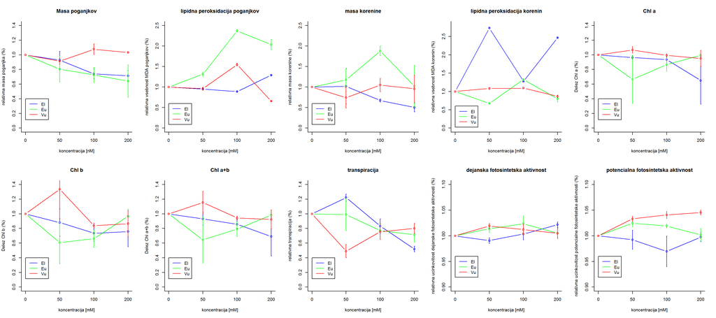

## 3.2 Boxplot

ustvarim boxplot za normalizirano maso poganjkov, s tem prikazom vidimo razlike v porazdelitvi podatkov, roza crta pri y=1 ponazarja kontrolo, tako lepo vidimo odstopanje vsakega tretmaja od slednje. Vsaka sorta je oznacena za svojo barvo za lazje razlikovanje.

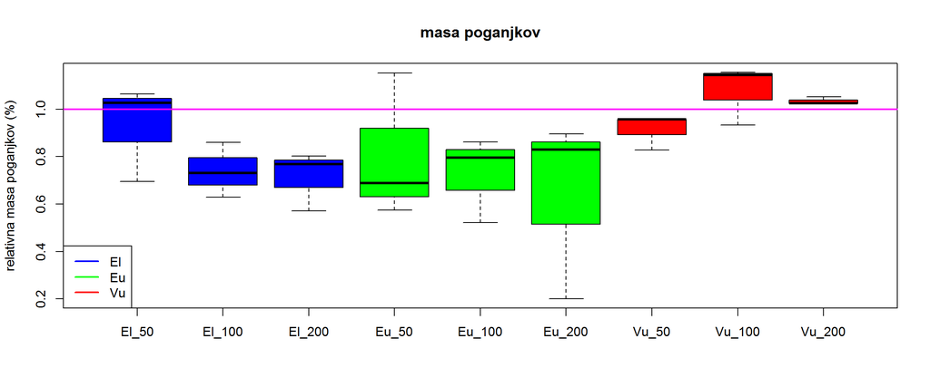

Enako kot zgoraj, izrisem se boxplote za vse ostale parametre, legenda je prikazana samo na prvem grafu.

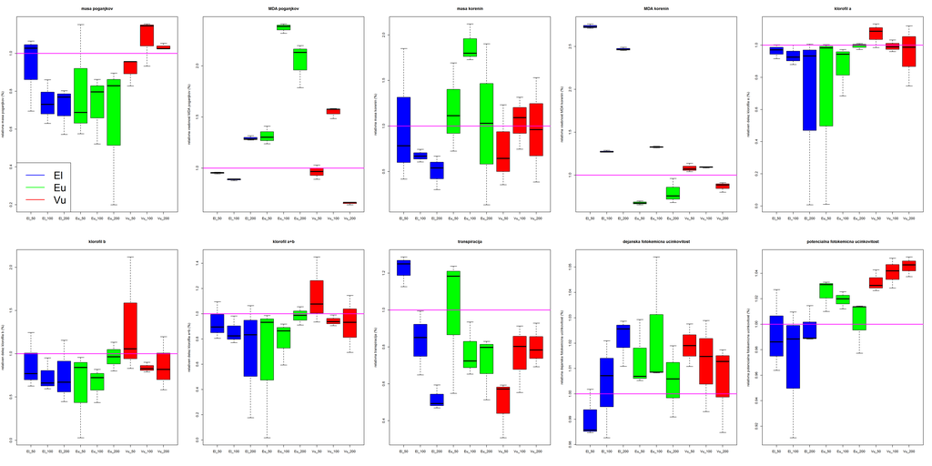

# 4 Analiza variance

Z analizo variance preverimo, ce so primerjane skupine podatkov (njihova povprecja) statisticno znacilo razlicne (ce so povprecja enaka ali ne).

Najprej ustvarim nov data.frame, v kterem locim konentracije in vrste.

```r
tabela444<-as.data.frame(tabela4)

u<-with(tabela444,strsplit(as.character(Vrsta_Kon), "_")) #with zacasno attacha
u<-unlist(u)
vrsta<-u[seq(1,length(u),by=2)] #vzame vsakega drugega, da dobimo vrste
kon<-u[seq(2,length(u),by=2)] #vzame vsakega drugega da bobimo koncentracije
#vrsta
#kon

tabela444$vrsta=vrsta #na tabela444 dodam stoplec z imenom 'vrsta' z vrednostmi iz 'vrsta'
tabela444$kon=kon #isto koz zgoraj, samo za koncentracijo
#tabela444
```

```r
aov1=aov(norm_MP ~ kon * vrsta ,tabela444[tabela444$kon!="K",])
summary(aov1)
```

```
##             Df Sum Sq Mean Sq F value Pr(>F)
## kon          2 0.0336 0.01682   0.414 0.6671
## vrsta        2 0.3946 0.19731   4.858 0.0206 *
## kon:vrsta    4 0.1321 0.03301   0.813 0.5333
## Residuals   18 0.7311 0.04062
## ---
## Signif. codes:  0 '***' 0.001 '**' 0.01 '*' 0.05 '.' 0.1 ' ' 1
```

## 4.1 Post hoc test

Z post hoc testom preverimo razmerja med skupinami, ki bi drugace ostana neopazena ([Post hoc analysis](https://en.wikipedia.org/wiki/Post_hoc_analysis)) glede na dani (v mojem primeru = 0.05). Naredil sem post hoc test za maso poganjkov. Duncanov test je posebaj popularen v agronomiji.

```r
model<-aov(norm_MP ~ Vrsta_Kon, data = tabela444)
comparison<-duncan.test(model,'Vrsta_Kon',main='hahah')
duncan.test(model,'Vrsta_Kon', alpha = 0.05, console=TRUE)
```

```
##
## Study: model ~ "Vrsta_Kon"
##
## Duncan's new multiple range test
## for norm_MP
##
## Mean Square Error:  0.03046204
##
## Vrsta_Kon,  means
##
##          norm_MP        std r       Min       Max
## El_100 0.7396965 0.11568819 3 0.6291474 0.8599167
## El_200 0.7141794 0.12485700 3 0.5713436 0.8025591
## El_50  0.9287308 0.20365983 3 0.6945395 1.0643505
## El_K   1.0000000 0.00000000 3 1.0000000 1.0000000
## Eu_100 0.7261978 0.18070105 3 0.5210381 0.8617168
## Eu_200 0.6413544 0.38372364 3 0.1999386 0.8953471
## Eu_50  0.8048219 0.30593713 3 0.5744779 1.1519502
## Eu_K   1.0000000 0.00000000 3 1.0000000 1.0000000
## Vu_100 1.0774040 0.12566754 3 0.9324204 1.1551057
## Vu_200 1.0339387 0.01598499 3 1.0247097 1.0523965
## Vu_50  0.9136648 0.07451201 3 0.8276273 0.9571301
## Vu_K   1.0000000 0.00000000 3 1.0000000 1.0000000
##
## alpha: 0.05 ; Df Error: 24
##
## Critical Range
##         2         3         4         5         6         7         8
## 0.2941184 0.3089127 0.3184114 0.3251205 0.3301287 0.3340029 0.3370743
##         9        10        11        12
## 0.3395518 0.3415754 0.3432427 0.3446247
##
## Means with the same letter are not significantly different.
##
## Groups, Treatments and means
## a     Vu_100      1.077
## ab    Vu_200      1.034
## ab    El_K        1
## ab    Eu_K        1
## ab    Vu_K        1
## abc   El_50       0.9287
## abc   Vu_50       0.9137
## abc   Eu_50       0.8048
## abc   El_100      0.7397
## bc    Eu_100      0.7262
## bc    El_200      0.7142
## c     Eu_200      0.6414
```

Z `interaction.plot` R samodejno izrise crtne grafe, rezultat je podoben kot sem storil ze zgoraj, vendar je pot do njega veliko enostavnejsa.

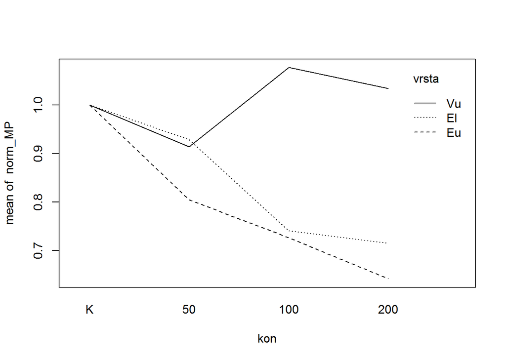

```r
tabela444$kon <- factor(tabela444$kon,levels=c("K","50","100","200")) #prerazporedim tabela444 da bo izrisann graf v zeljenem vrstnem redu

with(tabela444,

interaction.plot(kon,vrsta, norm_MP))
```

# 5 Normalnost razporeditve podatkov

Normalnost porazdelitve podatkov sem preveril z Shapirovim testom, ce je p < 0.05 pomeni da porazdelitev ni normalna, graficno jo prikazemo z QQ grafom, ce bi bila porazdelitev normalna, bi se podatki ujemali z linearno crto na grafu.

Razporeditev podatkov sem preveril z Shapiro–Wilk testom pri vseh merjenih parametrih in poiskal tiste, pri katerih je mormalna. Ce je vrednost p nizja od izbrane vrednosti lahko zavrnemo nicto hipotezo, da so podatki razporejeni normalno, ce je p visji, sorejmemo alternativno hipotezo, da so podatki normalno razporejeni.

```
##    p.value.2 p.value.7  p.value.8
## W 0.06980105 0.1984337 0.09248151
```

```
##         data.name.2           data.name.7
## W tabela444$norm_MK tabela444$Transp_norm
##                                  data.name.8
## W tabela444$norm_AVG_dejanska_foto_aktivnost
```

prikaz normalnosti razporeditve podatkov z QQ grafom (z funkcijama `qqnorm` in `qqline`), prvi graf prikazuje porazdelitev za maso poganjkov, ki je primer nenormalne porazdelitve, druga dva, za maso korenin in transpiracijo, sta primer normalne razporeditve podatkov, ceprav moram reci, da sam ne zaznam velike razlike med obema primeroma glede na graf.

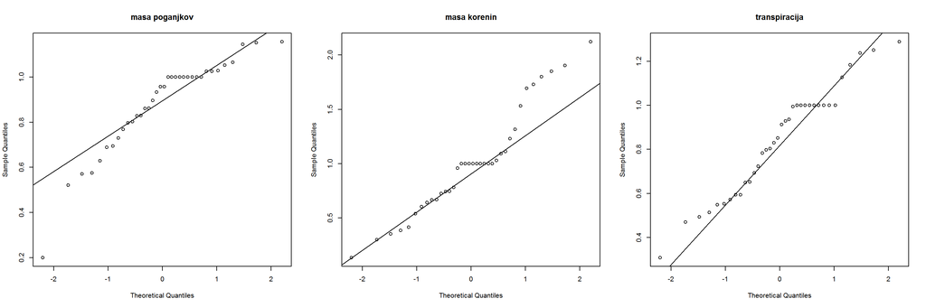

```r
par(mfrow=c(1,3))
qqnorm(tabela444[,'norm_MP'],main = 'masa poganjkov'); qqline(tabela444$norm_MP)
qqnorm(tabela444[,'norm_MK'],main = 'masa korenin'); qqline(tabela444$norm_MK)
qqnorm(tabela444[,'Transp_norm'],main = 'transpiracija'); qqline(tabela444$Transp_norm)
```

# 6 Homogenost variance

z Bartlett-ovim in Figner-Killeen-jevim testom preverim enakost varianc skupin, nicna hipoteza je da so variance enake, alternativna, da niso. Bartlettov je parametricen, ki je primeren za podatke z neko specificno razporeditvijo, Fignerjev test je neparametricni in je bolj primern za podatke, ki nimajo neke dolocene razporeditve, Levenov test gleda mediano, zato je bolj robusten za nenormalo razporejene podatke. Za moje podatke se mi zdi Barlettov test manj primeren ker nimam normalne distribucije podatkov.

Homogenost varianc za maso poganjkov

```r
# Bartlett Test of Homogeneity of Variances
bartlett.test(norm_MP~Vrsta_Kon, data=tabela444)
```

```
##
##  Bartlett test of homogeneity of variances
##
## data:  norm_MP by Vrsta_Kon
## Bartlett's K-squared = Inf, df = 11, p-value < 2.2e-16
```

```r
# Figner-Killeen Test of Homogeneity of Variances
fligner.test(norm_MP~Vrsta_Kon, data=tabela44)
```

```
##
##  Fligner-Killeen test of homogeneity of variances
##
## data:  norm_MP by Vrsta_Kon
## Fligner-Killeen:med chi-squared = 3.5205, df = 8, p-value = 0.8976
```

```r
#Brown-Forsyth Test of Homogeneity of Variances
hov(norm_MP~Vrsta_Kon, data=tabela444)
```

```
##
##  hov: Brown-Forsyth
##
## data:  norm_MP
## F = 0.78656, df:Vrsta_Kon = 11, df:Residuals = 24, p-value =
## 0.6509
## alternative hypothesis: variances are not identical
```

```r
#Levene Test of Homogeneity of Variances
levene.test(tabela444$norm_MP, tabela444$Vrsta_Kon)
```

```
##
##  modified robust Brown-Forsythe Levene-type test based on the
##  absolute deviations from the median
##
## data:  tabela444$norm_MP
## Test Statistic = 0.78656, p-value = 0.6509
```

Homogenost varianc za maso korenin

```r
# Bartlett Test of Homogeneity of Variances
bartlett.test(norm_MK~Vrsta_Kon, data=tabela444)
```

```
##
##  Bartlett test of homogeneity of variances
##
## data:  norm_MK by Vrsta_Kon
## Bartlett's K-squared = Inf, df = 11, p-value < 2.2e-16
```

```r
# Figner-Killeen Test of Homogeneity of Variances
fligner.test(norm_MK~Vrsta_Kon, data=tabela44)
```

```
##
##  Fligner-Killeen test of homogeneity of variances
##
## data:  norm_MK by Vrsta_Kon
## Fligner-Killeen:med chi-squared = 6.021, df = 8, p-value = 0.6449
```

```r
#Brown-Forsyth Test of Homogeneity of Variances
hov(norm_MK~Vrsta_Kon, data=tabela444)
```

```
##
##  hov: Brown-Forsyth
##
## data:  norm_MK
## F = 1.5707, df:Vrsta_Kon = 11, df:Residuals = 24, p-value = 0.1713
## alternative hypothesis: variances are not identical
```

```r
#Levene Test of Homogeneity of Variances
levene.test(tabela444$norm_MK, tabela444$Vrsta_Kon)
```

```
##
##  modified robust Brown-Forsythe Levene-type test based on the
##  absolute deviations from the median
##
## data:  tabela444$norm_MK
## Test Statistic = 1.5707, p-value = 0.1713
```

Spodaj sem s pomocjo `hovPlotBF` in `hovPlot` se graficno prikazal test za homogenost varianc, v prvem triu boxplotov za maso poganjkov v spodnjem pa za maso korenin. Na slikah je od leve proti desni prikazano: podatki (y), podatki z odsteto mediano (y-med(y)) in absolutna deviacija od mediane (and(y-med(y))).

```r
# Homogeneity of Variance Plot

hov(norm_MP~Vrsta_Kon, data=tabela44)#uporabim tabelo 44 kr nima kontrol, kr so itak 1
```

```
##
##  hov: Brown-Forsyth
##
## data:  norm_MP
## F = 0.5003, df:Vrsta_Kon = 8, df:Residuals = 18, p-value = 0.8403
## alternative hypothesis: variances are not identical
```

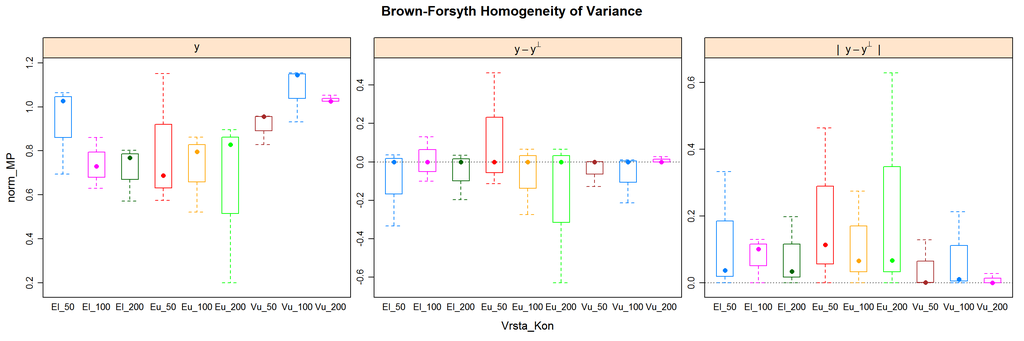

```r
hovplotBF(norm_MP~Vrsta_Kon, data=tabela44)
```

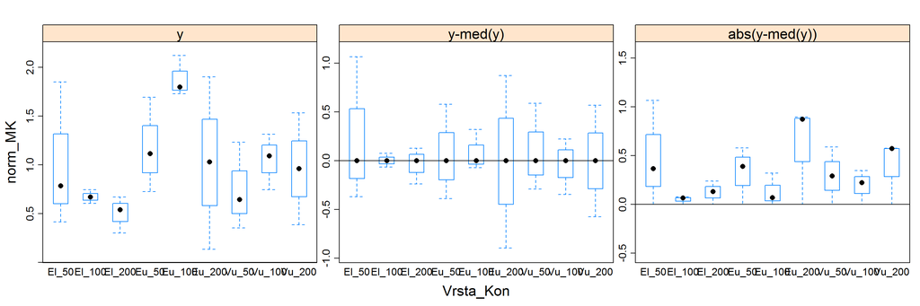

```r
hovPlot(norm_MK~Vrsta_Kon, data=tabela44)
```

# 7 Transformacija podatkov

Podatke transformiramo z namenom, da dosezemo normalnost razporeditve pred nadalnjo obdelavo (npr. ANOVA). Sam za te namene nisem uporabil transformiranih podatkov, to sem storil zato, da si ogledam kako transformacija deluje. Preizkusil sem vec oblik transformacije; logaritemsko (z osnovami 10, 2 in naravnim), kvadratni koren in z-transformacijo.

```r
sqrt_tabela4 <- sqrt(tabela4[,2:11])
sqrt_tabela4<-cbind(tabela4$Vrsta_Kon,sqrt_tabela4)
colnames (sqrt_tabela4) <- (c('Vrsta_Kon','norm_MP','norm_MDA_P', 'norm_MK','norm_MDA_K','Chla_Qorm','Chlb_norm','Sk_Chl_norm','Transp_norm','norm_AVG_dejanska_foto_aktivnost','norm_AVG-potencialna_foto_aktivnost'))
#sqrt_tabela4
```

```r
log_tabela4 <- log(tabela4[,2:11])
log_tabela4<-cbind(tabela4$Vrsta_Kon,log_tabela4)
colnames (log_tabela4) <- (c('Vrsta_Kon','norm_MP','norm_MDA_P', 'norm_MK','norm_MDA_K','Chla_Qorm','Chlb_norm','Sk_Chl_norm','Transp_norm','norm_AVG_dejanska_foto_aktivnost','norm_AVG-potencialna_foto_aktivnost'))
#log_tabela4
```

```r
log10_tabela4 <- log10(tabela4[,2:11])
log10_tabela4<-cbind(tabela4$Vrsta_Kon,log10_tabela4)
colnames (log10_tabela4) <- (c('Vrsta_Kon','norm_MP','norm_MDA_P', 'norm_MK','norm_MDA_K','Chla_Qorm','Chlb_norm','Sk_Chl_norm','Transp_norm','norm_AVG_dejanska_foto_aktivnost','norm_AVG-potencialna_foto_aktivnost'))
#log10_tabela4
```

```r
log2_tabela4 <- log2(tabela4[,2:11])
log2_tabela4<-cbind(tabela4$Vrsta_Kon,log2_tabela4)
colnames (log2_tabela4) <- (c('Vrsta_Kon','norm_MP','norm_MDA_P', 'norm_MK','norm_MDA_K','Chla_Qorm','Chlb_norm','Sk_Chl_norm','Transp_norm','norm_AVG_dejanska_foto_aktivnost','norm_AVG-potencialna_foto_aktivnost'))
#log2_tabela4
```

```r
z_tabela444<-(tabela444$norm_MP - mean(tabela444$norm_MP)) / sd(tabela444$norm_MP)
#z_tabela444
```

Preverjanje normalnosti razporeditve transformiranih podatkov z Shapiro testom za logaritemsko transformacijo z osnovo 10. Po transformaciji ima samo en parameter normalno razporeditev.

```r
u<-c(
shapiro.test(log10_tabela4$norm_MP),
shapiro.test(log10_tabela4$norm_MDA_P),
shapiro.test(log10_tabela4$norm_MK),
shapiro.test(log10_tabela4$norm_MDA_K),
shapiro.test(log10_tabela4$Chla_Qorm),
shapiro.test(log10_tabela4$Chlb_norm),
shapiro.test(log10_tabela4$Sk_Chl_norm),
shapiro.test(log10_tabela4$Transp_norm),
shapiro.test(log10_tabela4$norm_AVG_dejanska_foto_aktivnost),
shapiro.test(log10_tabela4[,'norm_AVG-potencialna_foto_aktivnost'])) #shapiro teste za vsak merjen parameter spravim v vektor, shrani se kot 'list'

u<-as.data.frame(u) #u spremenim v data.frame

p<-u[seq(2, length(u),by=4)] #shapiro test prikaze tudi W in imena parametrov, v vektor p spravim samo p vrednosti
pp<-colnames(p) # v vektor pp spravim samo imena stolpcev z p vrednostmi iz p
uu<-p>= 0.05 # v vektor uu preverim katere p vrednosti so vecje od 0.05, kar pomeni, da je razdelitev verjetno normalna
uuu<-grep('TRUE',uu) #u uuu spravum samo tiste, ki so vecji od 0.05
p[uuu] #in jih izpisem, vidim da je to p vrednosti 8
```

```
##   p.value.8
## W 0.1148964
```

```r
u[c('data.name.8')] #poiscem katerim parametrom pripadajo slednje p vrednosti, to je sedaj samo norm_AVG_dejanska_foto_aktivnost, pri teh tem parametru naj bi bila rezporeditev normalna
```

```
##                                      data.name.8
## W log10_tabela4$norm_AVG_dejanska_foto_aktivnost
```

Vizualizacija normalnosi razporeditve normiranih podatkov za vse izvedene transformacije, lepo se vidi, da ekstremne vrednosti ostanejo osamljene, medtem ko se srednje zgostijo.

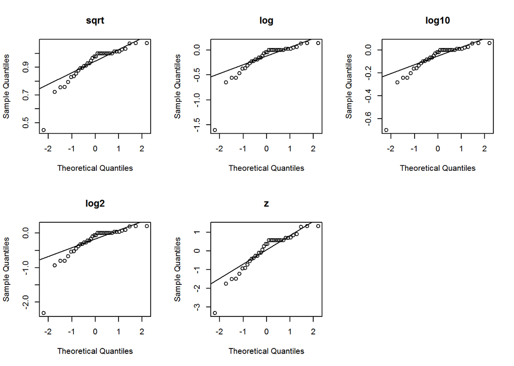

```r
par(mfrow=c(2,3))

qqnorm(sqrt_tabela4$norm_MP,main = 'sqrt'); qqline(sqrt_tabela4$norm_MP)
qqnorm(log_tabela4[,'norm_MP'],main = 'log'); qqline(log_tabela4$norm_MP)
qqnorm(log10_tabela4[,'norm_MP'],main = 'log10'); qqline(log10_tabela4$norm_MP)
qqnorm(log2_tabela4[,'norm_MP'],main = 'log2'); qqline(log2_tabela4$norm_MP)
qqnorm(z_tabela444,main = 'z'); qqline(z_tabela444)
```

```r
# Bartlett Test of Homogeneity of Variances
bartlett.test(norm_MP~Vrsta_Kon, data=log10_tabela4)
```

```
##
##  Bartlett test of homogeneity of variances
##
## data:  norm_MP by Vrsta_Kon
## Bartlett's K-squared = Inf, df = 11, p-value < 2.2e-16
```

```r
# Figner-Killeen Test of Homogeneity of Variances
fligner.test(norm_MP~Vrsta_Kon, data=log10_tabela4)
```

```
##
##  Fligner-Killeen test of homogeneity of variances
##
## data:  norm_MP by Vrsta_Kon
## Fligner-Killeen:med chi-squared = 11.32, df = 11, p-value = 0.4169
```

```r
#Brown-Forsyth Test of Homogeneity of Variances
hov(norm_MP~Vrsta_Kon, data=log10_tabela4)
```

```
##
##  hov: Brown-Forsyth
##
## data:  norm_MP
## F = 0.84733, df:Vrsta_Kon = 11, df:Residuals = 24, p-value =
## 0.5984
## alternative hypothesis: variances are not identical
```

```r
#Levene Test of Homogeneity of Variances
levene.test(log10_tabela4$norm_MP, log10_tabela4$Vrsta_Kon)
```

```
##
##  modified robust Brown-Forsythe Levene-type test based on the
##  absolute deviations from the median
##
## data:  log10_tabela4$norm_MP
## Test Statistic = 0.84733, p-value = 0.5984
```

```r
log10_tabela4SE <-aggregate(log10_tabela4[,2:11], by=list(tabela4$Vrsta_Kon),FUN=se)
log10_tabela4SE<-log10_tabela4SE[match(row.names(imena),log10_tabela4SE$Group.1),]
colnames(log10_tabela4SE)<- c(colnames(tabela))
#log10_tabela4SE
```

```r
shapiro.test(log10_tabela4SE$`AVG-masa-pog`)
```

```
##
##  Shapiro-Wilk normality test
##
## data:  log10_tabela4SE$`AVG-masa-pog`
## W = 0.7684, p-value = 0.004188
```

```r
shapiro.test(tabelaSE$norm_MP)
```

```
##
##  Shapiro-Wilk normality test
##
## data:  tabelaSE$norm_MP
## W = 0.89666, p-value = 0.1436
```

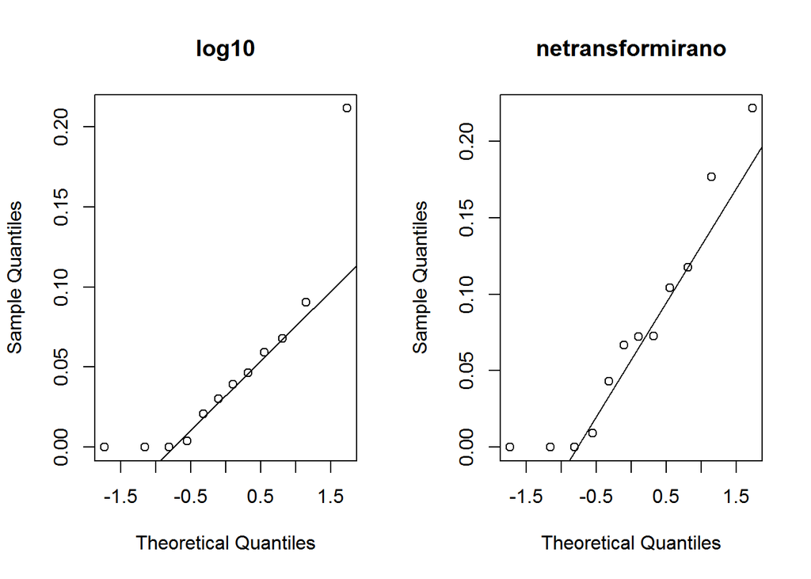

```r
par(mfrow=c(1,2))

qqnorm(log10_tabela4SE$`AVG-masa-pog`,main = 'log10'); qqline(log10_tabela4SE$`AVG-masa-pog`)
qqnorm(tabelaSE$norm_MP,main = 'netransformirano');qqline(tabelaSE$norm_MP)
```

# 8 Multivariatna analiza

Multivariatno analizo podatkov lahko prikazemo na vec nacinov.

## 8.1 Dendrogram

Pri prikazu z dendrogramom so bolj podobni/povezani podatki povezani z krajso razdaljo, spodaj so trije razlicni nacini prikaza dendrograma, podatki v obliki `hc` izrisani z pomocjo `plot`

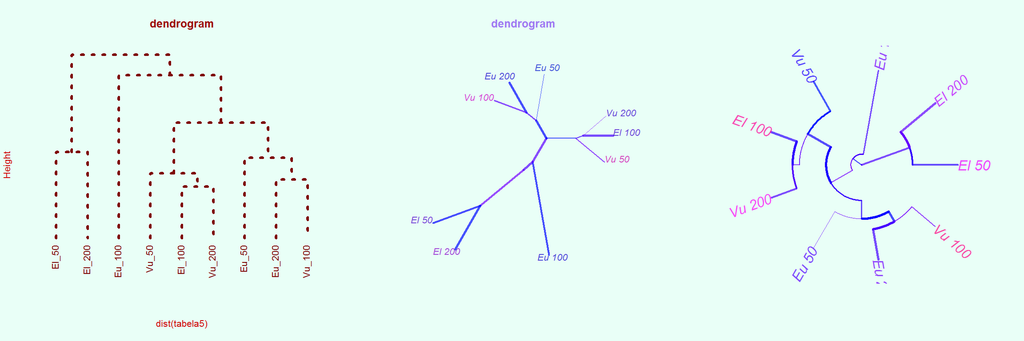

```r
hc = hclust(dist(tabela5))

par(bg='#e9fff7',mfrow=c(1,3))

plot(hc, col = "#7e0606", col.main = "#9c0a0a", col.lab = "#d00d0d",
    col.axis = "#d00d0d", lwd = 3, lty = 3, sub = "", hang = -1, axes = FALSE, main = 'dendrogram')

plot(as.phylo(hc), type = "unrooted", col.main='#bfefff',main = 'dendrogram',col.main = '#9f79f2',tip.color = hsv(runif(100, 0.65,
    0.95), 1, 0.8, 0.7), edge.color = hsv(runif(10, 0.65, 0.75), 1, 1, 0.7), edge.width = runif(20,
    0.5, 3), use.edge.length = TRUE, cex = 1)

plot(as.phylo(hc), type = "fan", tip.color = hsv(runif(15, 0.65,
    0.95), 1, 1, 0.7), edge.color = hsv(runif(10, 0.65, 0.75), 1, 1, 0.7), edge.width = runif(20,
    0.5, 3), use.edge.length = TRUE, col = "#580606",cex = 1.5)
```

## 8.2 Heatmap

Na heatmap so bolj podobni podatki prikazani z podobno barvo, dodatno je povezanost podatkov v stolpcih in vrsticah prikazana z dendrogrami. Spodnja heatmapa sta izrisana z `heatmap` in `heatmap.2`. Pri drugem je na legendi prikazana tudi frekvenca s katero se posamezna barva pojavi.

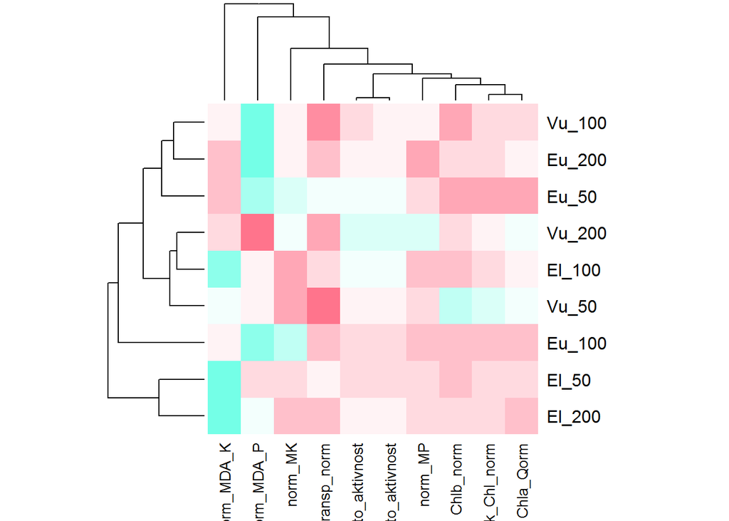

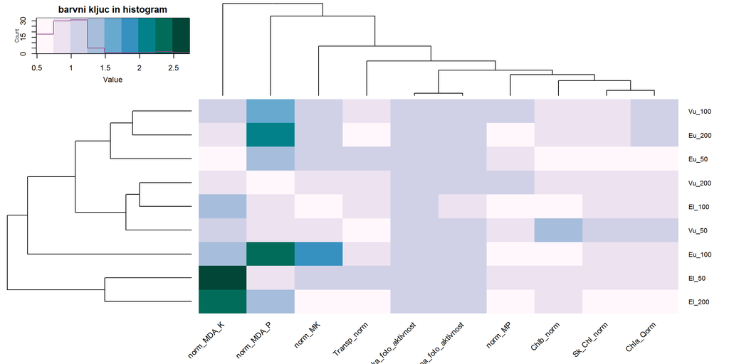

## 8.3 Correlogram

Z correlogramom lahko graficno prikazem korelacijo (linearno odvisnost) med skupinami. Najprej sem z `rcorr` dobil rezultate za Pearsonovo in Spearmanovo korelacijo. Rezultat 1 pomeni pozitivno, 0 linearno, -1 pa negativno korelacijo med podatki. Rezultatov `rcorr` ne izpisem, saj je na spodnjih dveh slikah to prikazano malo lepse z `corrgram`. Izkaze se, da med merjenimi parametri vecinoma korelacij, razen mocna pozitivna med delezem vsakega posameznega klorofila in delezem skupnih klorofilov, kar je za pricakovati, saj so je podatek za skupne klorofile sestavljen iz podatkov za klorofila a in b. Negativno korelacijo lahko opazimo med transpiracijo in dejansko fotokemicno ucinkovitostjo, skoraj linearno, brez korelacije, pa so podatki za maso korenin in delezem klorofila a, kar ne preseneca, saj v koreninah ni klorofila.

```r
rcorr(tabela55, type="pearson")

rcorr(tabela55, type="spearman")
```

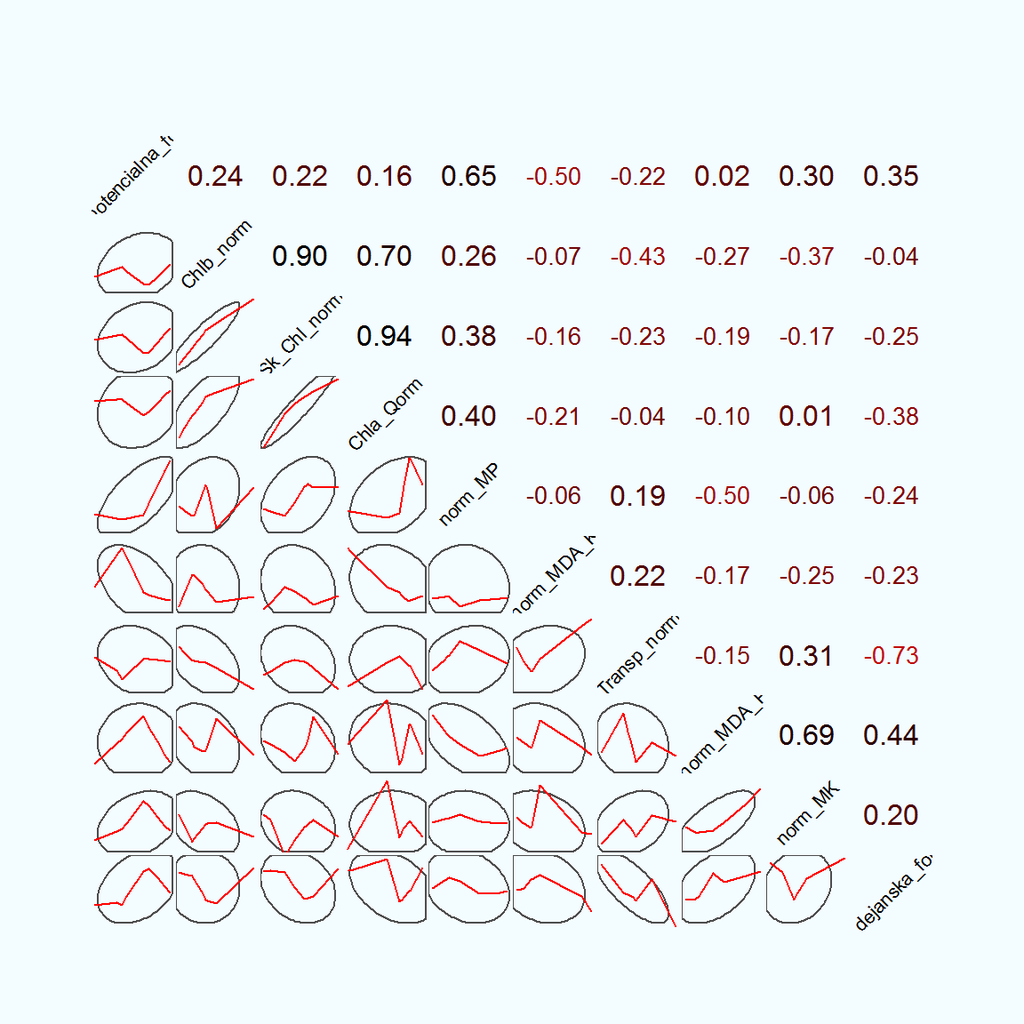

```r
col.corrgram <- function(ncol){
  colorRampPalette(c(mypalette7))(ncol)}
par(bg='#f3fcff')
corrgram(tabela55, order=TRUE, lower.panel=panel.ellipse,
  upper.panel=panel.cor, text.panel=panel.txt,
  main=" ", col.regions = col.corrgram, gap = 0.15, cex.labels = 1, label.srt = 45)
```

[figure not shown]

```r
col.corrgram <- function(ncol){
  colorRampPalette(c(mypalette6))(ncol)}
par(bg='#f3fcff')
corrgram(tabela55, order=TRUE, lower.panel=panel.shade,
  upper.panel=panel.pie, text.panel=panel.txt,
  main=" ", col.regions = col.corrgram, label.srt = 0, row1attop = FALSE, gap = 0.1)
```

## 8.4 Analiza glavnih komponent

Z analizo glavnih komponent semerjene spremenljivke z ortologno transformacijo pretvorijo v glavne komponente ([PCA]https://en.wikipedia.org/wiki/Principal_component_analysis), razporejene so tako, da ima prva najvecjo varianco in tako prispeva najvec variabilnosti podatkom.

PCA dobim z `princomp`, jih povzamem z `summary` in kot v obliki histograma ali crtnega grafa izrisem z `screenplot`, lepo se vidi, da so glavne komponente razporejene po padajocem delezu variance, ki jo prispevajo.

```r
summary(pca)
```

```
## Importance of components:
##                           Comp.1    Comp.2    Comp.3    Comp.4     Comp.5
## Standard deviation     1.7283411 1.4201587 1.2025751 1.1052704 0.91080427
## Proportion of Variance 0.2987163 0.2016851 0.1446187 0.1221623 0.08295644
## Cumulative Proportion  0.2987163 0.5004014 0.6450201 0.7671823 0.85013877
##                            Comp.6     Comp.7     Comp.8     Comp.9
## Standard deviation     0.75717960 0.72226343 0.52131022 0.36267281
## Proportion of Variance 0.05733209 0.05216645 0.02717643 0.01315316
## Cumulative Proportion  0.90747086 0.95963731 0.98681374 0.99996690
##                             Comp.10
## Standard deviation     1.819309e-02
## Proportion of Variance 3.309886e-05
## Cumulative Proportion  1.000000e+00
```

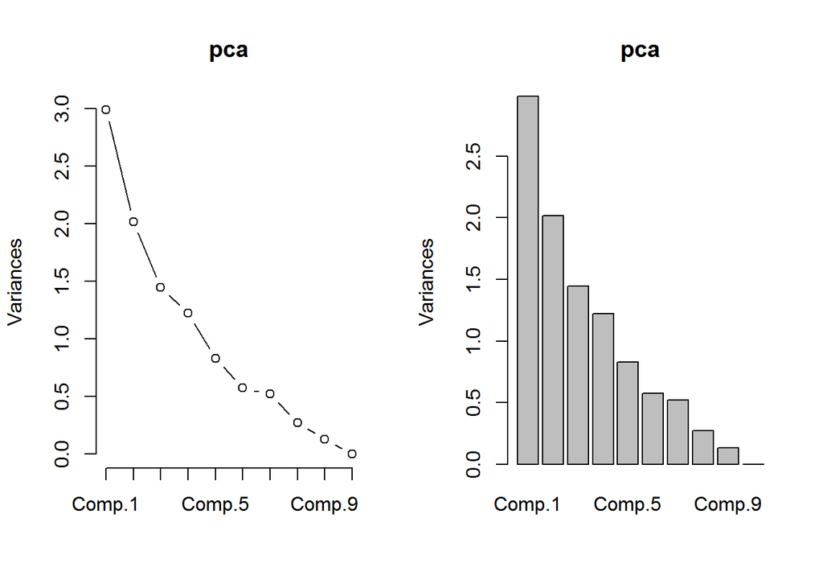

Z `plot` izrisem rezultate pca glede na komponenti 1 in 2, ki prispevata najvec, krizci so Vu, krozci El in trikotniki Eu.

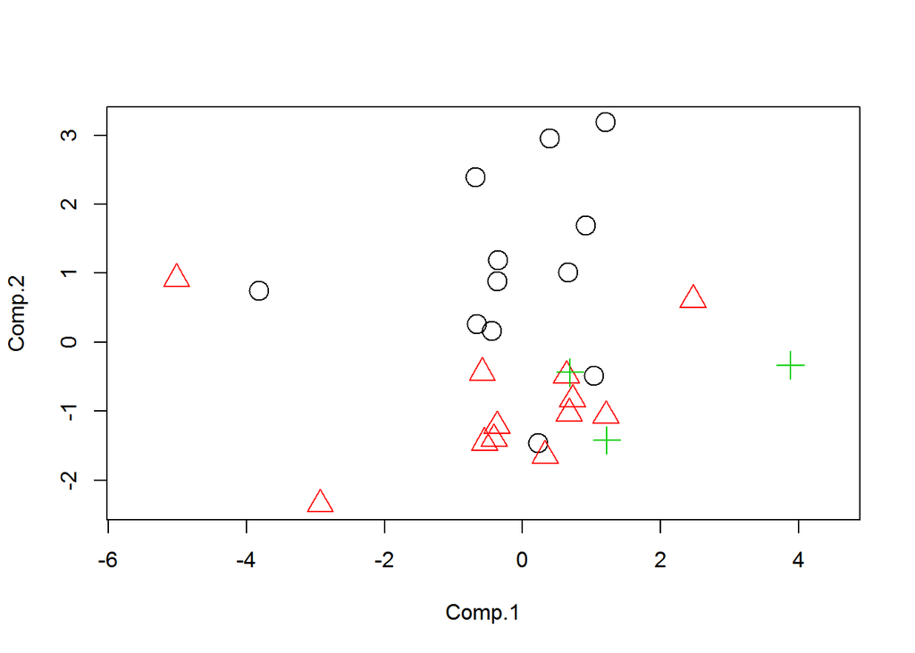

```r
plot(pca$scores,col=sorte[,1],lwd=1,asp=1, cex=2, pch=as.numeric(c(sorte[,1])))
```

Z `biplot` graficno prikazem koliko vsak merjen parameter prispeva k variabilnosti podatkov, zaradi gostote puscic se na zalost ne da razbrati dobro.

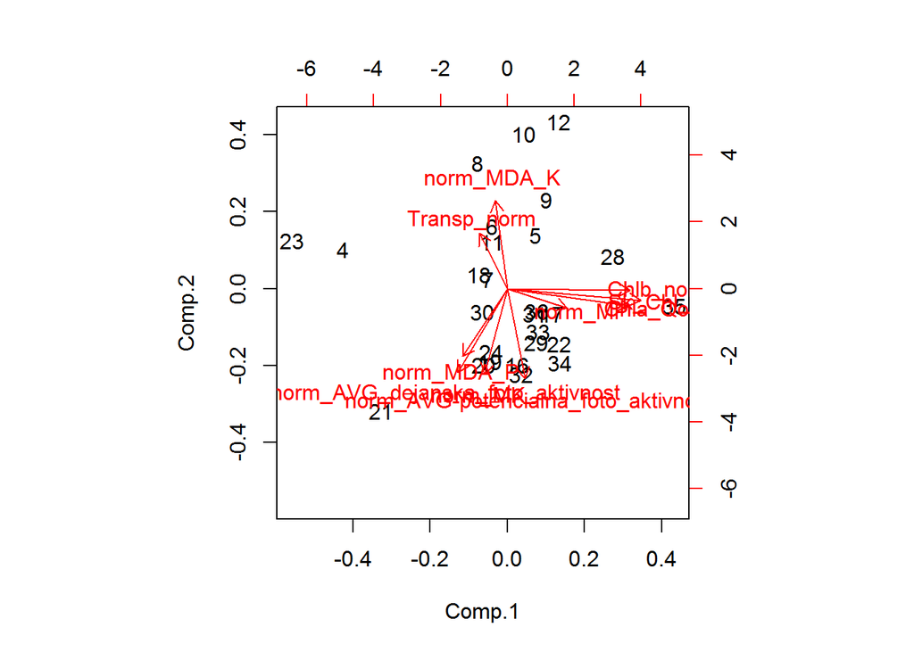

```r
biplot(pca)
```

# 9 Linearna diskriminacijska analiza

Z linearno diskriminacijsko analizo se podatki pogledajo tako, da so razlike med njimi najvecje, poiscejo se komponente, ki pojasnujejo najvec variabilnosti med skupinami in se na podlagi tega locijo v naprej dolocene skupine. Na grafu vidim, da se locijo zelo uspesno.

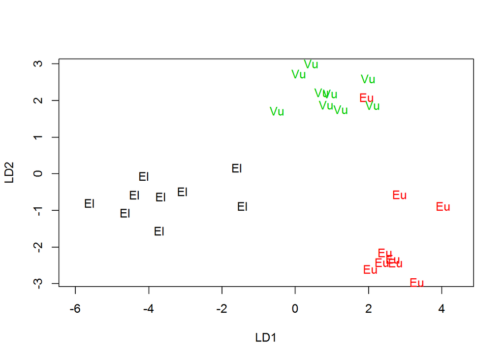

# 10 Linearni model

Z sledecimi vrsticami dobim kar nekaj podatkov, za vse ne vem kaj pomenijo, za tiste, ki pa, se mi zdijo kar uporabni.

```r
#tale chunk drugace dela, samo knit zanj ne mara

#lm1 <- lm(tabela4444~0+factor(tabela444[,12])+factor(tabela444[,11]))
#lm1
#summary(lm1)
```

```r
fit <- lm(norm_MP ~ vrsta * kon, data=tabela444)
summary(fit)
```

```
##
## Call:
## lm(formula = norm_MP ~ vrsta * kon, data = tabela444)
##
## Residuals:
##      Min       1Q   Median       3Q      Max
## -0.44142 -0.02876  0.00000  0.07166  0.34713
##
## Coefficients:
##                  Estimate Std. Error t value Pr(>|t|)
## (Intercept)     1.000e+00  1.008e-01   9.924 5.71e-10 ***
## vrstaEu         4.144e-16  1.425e-01   0.000   1.0000
## vrstaVu         4.328e-16  1.425e-01   0.000   1.0000
## kon50          -7.127e-02  1.425e-01  -0.500   0.6216
## kon100         -2.603e-01  1.425e-01  -1.827   0.0802 .
## kon200         -2.858e-01  1.425e-01  -2.006   0.0563 .
## vrstaEu:kon50  -1.239e-01  2.015e-01  -0.615   0.5445
## vrstaVu:kon50  -1.507e-02  2.015e-01  -0.075   0.9410
## vrstaEu:kon100 -1.350e-02  2.015e-01  -0.067   0.9472
## vrstaVu:kon100  3.377e-01  2.015e-01   1.676   0.1068
## vrstaEu:kon200 -7.283e-02  2.015e-01  -0.361   0.7210
## vrstaVu:kon200  3.198e-01  2.015e-01   1.587   0.1257
## ---
## Signif. codes:  0 '***' 0.001 '**' 0.01 '*' 0.05 '.' 0.1 ' ' 1
##
## Residual standard error: 0.1745 on 24 degrees of freedom
## Multiple R-squared:  0.4991, Adjusted R-squared:  0.2695
## F-statistic: 2.174 on 11 and 24 DF,  p-value: 0.05422
```

```r
coefficients(fit)
```

```
##    (Intercept)        vrstaEu        vrstaVu          kon50         kon100
##   1.000000e+00   4.144413e-16   4.327531e-16  -7.126916e-02  -2.603035e-01
##         kon200  vrstaEu:kon50  vrstaVu:kon50 vrstaEu:kon100 vrstaVu:kon100
##  -2.858206e-01  -1.239090e-01  -1.506606e-02  -1.349869e-02   3.377075e-01
## vrstaEu:kon200 vrstaVu:kon200
##  -7.282501e-02   3.197592e-01
```

```r
confint(fit, level=0.95)
```

```
##                      2.5 %      97.5 %
## (Intercept)     0.79202688 1.207973122
## vrstaEu        -0.29411841 0.294118410
## vrstaVu        -0.29411841 0.294118410
## kon50          -0.36538757 0.222849254
## kon100         -0.55442194 0.033814884
## kon200         -0.57993897 0.008297848
## vrstaEu:kon50  -0.53985522 0.292037268
## vrstaVu:kon50  -0.43101231 0.400880182
## vrstaEu:kon100 -0.42944493 0.402447559
## vrstaVu:kon100 -0.07823873 0.753653760
## vrstaEu:kon200 -0.48877126 0.343121229
## vrstaVu:kon200 -0.09618701 0.735705479
```

```r
fitted(fit) # predvidene vrednosti
```

```
##         1         2         3         4         5         6         7
## 1.0000000 1.0000000 1.0000000 0.7141794 0.7141794 0.7141794 0.7396965
##         8         9        10        11        12        13        14
## 0.7396965 0.7396965 0.9287308 0.9287308 0.9287308 1.0000000 1.0000000
##        15        16        17        18        19        20        21
## 1.0000000 0.6413544 0.6413544 0.6413544 0.7261978 0.7261978 0.7261978
##        22        23        24        25        26        27        28
## 0.8048219 0.8048219 0.8048219 1.0000000 1.0000000 1.0000000 1.0339387
##        29        30        31        32        33        34        35
## 1.0339387 1.0339387 1.0774040 1.0774040 1.0774040 0.9136648 0.9136648
##        36
## 0.9136648
```

```r
residuals(fit)
```

```
##             1             2             3             4             5
## -8.274631e-16  5.028220e-16  2.683664e-16  8.837971e-02 -1.428359e-01
##             6             7             8             9            10
##  5.445618e-02 -1.105490e-01  1.202202e-01 -9.671180e-03  9.857164e-02
##            11            12            13            14            15
##  1.356197e-01 -2.341913e-01  9.613544e-18  9.613544e-18  9.613544e-18
##            16            17            18            19            20
##  1.874232e-01  2.539926e-01 -4.414158e-01  1.355190e-01  6.964066e-02
##            21            22            23            24            25
## -2.051597e-01  3.471284e-01 -2.303440e-01 -1.167844e-01  3.612495e-17
##            26            27            28            29            30
##  3.612495e-17  3.612495e-17 -9.228937e-03 -9.228937e-03  1.845787e-02
##            31            32            33            34            35
##  6.728193e-02  7.770170e-02 -1.449836e-01  4.257219e-02  4.346532e-02
##            36
## -8.603751e-02
```

```r
anova(fit)
```

```
## Analysis of Variance Table
##
## Response: norm_MP
##           Df  Sum Sq  Mean Sq F value  Pr(>F)
## vrsta      2 0.29597 0.147983  4.8579 0.01692 *
## kon        3 0.20167 0.067222  2.2068 0.11338
## vrsta:kon  6 0.23071 0.038451  1.2623 0.31130
## Residuals 24 0.73109 0.030462
## ---
## Signif. codes:  0 '***' 0.001 '**' 0.01 '*' 0.05 '.' 0.1 ' ' 1
```

```r
vcov(fit)
```

```
##                (Intercept)     vrstaEu     vrstaVu       kon50      kon100
## (Intercept)     0.01015401 -0.01015401 -0.01015401 -0.01015401 -0.01015401
## vrstaEu        -0.01015401  0.02030803  0.01015401  0.01015401  0.01015401
## vrstaVu        -0.01015401  0.01015401  0.02030803  0.01015401  0.01015401
## kon50          -0.01015401  0.01015401  0.01015401  0.02030803  0.01015401
## kon100         -0.01015401  0.01015401  0.01015401  0.01015401  0.02030803
## kon200         -0.01015401  0.01015401  0.01015401  0.01015401  0.01015401
## vrstaEu:kon50   0.01015401 -0.02030803 -0.01015401 -0.02030803 -0.01015401
## vrstaVu:kon50   0.01015401 -0.01015401 -0.02030803 -0.02030803 -0.01015401
## vrstaEu:kon100  0.01015401 -0.02030803 -0.01015401 -0.01015401 -0.02030803
## vrstaVu:kon100  0.01015401 -0.01015401 -0.02030803 -0.01015401 -0.02030803
## vrstaEu:kon200  0.01015401 -0.02030803 -0.01015401 -0.01015401 -0.01015401
## vrstaVu:kon200  0.01015401 -0.01015401 -0.02030803 -0.01015401 -0.01015401
##                     kon200 vrstaEu:kon50 vrstaVu:kon50 vrstaEu:kon100
## (Intercept)    -0.01015401    0.01015401    0.01015401     0.01015401
## vrstaEu         0.01015401   -0.02030803   -0.01015401    -0.02030803
## vrstaVu         0.01015401   -0.01015401   -0.02030803    -0.01015401
## kon50           0.01015401   -0.02030803   -0.02030803    -0.01015401
## kon100          0.01015401   -0.01015401   -0.01015401    -0.02030803
## kon200          0.02030803   -0.01015401   -0.01015401    -0.01015401
## vrstaEu:kon50  -0.01015401    0.04061605    0.02030803     0.02030803
## vrstaVu:kon50  -0.01015401    0.02030803    0.04061605     0.01015401
## vrstaEu:kon100 -0.01015401    0.02030803    0.01015401     0.04061605
## vrstaVu:kon100 -0.01015401    0.01015401    0.02030803     0.02030803
## vrstaEu:kon200 -0.02030803    0.02030803    0.01015401     0.02030803
## vrstaVu:kon200 -0.02030803    0.01015401    0.02030803     0.01015401
##                vrstaVu:kon100 vrstaEu:kon200 vrstaVu:kon200
## (Intercept)        0.01015401     0.01015401     0.01015401
## vrstaEu           -0.01015401    -0.02030803    -0.01015401
## vrstaVu           -0.02030803    -0.01015401    -0.02030803
## kon50             -0.01015401    -0.01015401    -0.01015401
## kon100            -0.02030803    -0.01015401    -0.01015401
## kon200            -0.01015401    -0.02030803    -0.02030803
## vrstaEu:kon50      0.01015401     0.02030803     0.01015401
## vrstaVu:kon50      0.02030803     0.01015401     0.02030803
## vrstaEu:kon100     0.02030803     0.02030803     0.01015401
## vrstaVu:kon100     0.04061605     0.01015401     0.02030803
## vrstaEu:kon200     0.01015401     0.04061605     0.02030803
## vrstaVu:kon200     0.02030803     0.02030803     0.04061605
```

```r
influence(fit)
```

```
## $hat
##         1         2         3         4         5         6         7
## 0.3333333 0.3333333 0.3333333 0.3333333 0.3333333 0.3333333 0.3333333
##         8         9        10        11        12        13        14
## 0.3333333 0.3333333 0.3333333 0.3333333 0.3333333 0.3333333 0.3333333
##        15        16        17        18        19        20        21
## 0.3333333 0.3333333 0.3333333 0.3333333 0.3333333 0.3333333 0.3333333
##        22        23        24        25        26        27        28
## 0.3333333 0.3333333 0.3333333 0.3333333 0.3333333 0.3333333 0.3333333
##        29        30        31        32        33        34        35
## 0.3333333 0.3333333 0.3333333 0.3333333 0.3333333 0.3333333 0.3333333
##        36
## 0.3333333
##
## $coefficients
```

[output cut: 143 more lines]

Vpliv vrste in koncentracije na tezo poganjka;

```r
fit<- lm(norm_MP~kon*vrsta,tabela444[tabela444$kon!="K",] )
fit
```

```
##
## Call:
## lm(formula = norm_MP ~ kon * vrsta, data = tabela444[tabela444$kon !=
##     "K", ])
##
## Coefficients:
##    (Intercept)          kon100          kon200         vrstaEu
##        0.92873        -0.18903        -0.21455        -0.12391
##        vrstaVu  kon100:vrstaEu  kon200:vrstaEu  kon100:vrstaVu
##       -0.01507         0.11041         0.05108         0.35277
## kon200:vrstaVu
##        0.33483
```

```r
predict(fit)
```

```
##         4         5         6         7         8         9        10
## 0.7141794 0.7141794 0.7141794 0.7396965 0.7396965 0.7396965 0.9287308
##        11        12        16        17        18        19        20
## 0.9287308 0.9287308 0.6413544 0.6413544 0.6413544 0.7261978 0.7261978
##        21        22        23        24        28        29        30
## 0.7261978 0.8048219 0.8048219 0.8048219 1.0339387 1.0339387 1.0339387
##        31        32        33        34        35        36
## 1.0774040 1.0774040 1.0774040 0.9136648 0.9136648 0.9136648
```

```r
#aggregate(norm_MP~vrsta, FUN=mean) #povzetek nardi, povpreÄŤja
anova(fit)
```

```
## Analysis of Variance Table
##
## Response: norm_MP
##           Df  Sum Sq  Mean Sq F value  Pr(>F)
## kon        2 0.03363 0.016816  0.4140 0.66713
## vrsta      2 0.39462 0.197310  4.8579 0.02055 *
## kon:vrsta  4 0.13205 0.033013  0.8128 0.53334
## Residuals 18 0.73109 0.040616
## ---
## Signif. codes:  0 '***' 0.001 '**' 0.01 '*' 0.05 '.' 0.1 ' ' 1
```

```r
residuals(fit)
```

```
##            4            5            6            7            8
##  0.088379705 -0.142835888  0.054456182 -0.110549025  0.120220205
##            9           10           11           12           16
## -0.009671180  0.098571641  0.135619699 -0.234191341  0.187423219
##           17           18           19           20           21
##  0.253992629 -0.441415848  0.135519042  0.069640663 -0.205159705
##           22           23           24           28           29
##  0.347128378 -0.230343980 -0.116784398 -0.009228937 -0.009228937
##           30           31           32           33           34
##  0.018457874  0.067281929  0.077701697 -0.144983626  0.042572194
##           35           36
##  0.043465317 -0.086037511
```